# Seurat workflow of Gg_D05_ctrl

Fabio Sacher

06.02.2023

```r
library(Seurat)
```

```r
library(dplyr)
```

```r
library(Rtsne)
library(RColorBrewer)
library(tidyr)
library(ggplot2)
library(gridExtra)
```

```r
library(patchwork)
library(cowplot)
```

```r
library(ggdendro)
```

```r
gnames<- modplots::gnames

# here we need to load all the datasets that will be part of our analysis
my.samples <- list()

my.samples[[1]] <- readRDS("~/spinal_cord_paper/data/D05_ctrl_filtered_070323.rds")

#The sample name, will  be used in plots and files
my.samplename <- "Gg_D05_ctrl"
```

Date: 07.03.23

This script takes filtered seurat objects from ddqc and then runs our pipeline using Seurat and other packages to analyse the cells.

# Build object

First, we build the Seurat object.

```r
# are there several datasets?
my.multi <- F
my.samplenames <- c()

my.se <- CreateSeuratObject(my.samples[[1]], project = my.samplename)
my.se
#clean
rm(my.samples)

rm(my.samplenames)
```

# Transformation & inspection

Now, we do some normalization steps, and we can see what’s the amount of UMIs, genes and percentage of MT reads

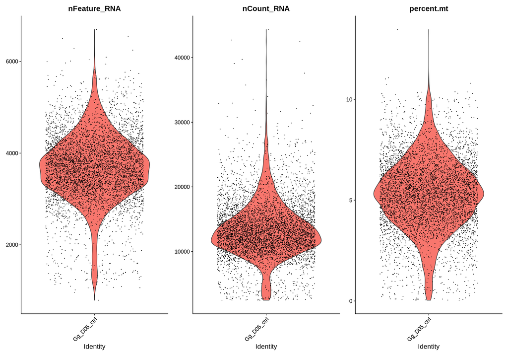

```r
mt <- c("ENSGALG00000035334", #COX3
     "ENSGALG00000032142", #MT-CO1
     "ENSGALG00000032079", #MT-CYB
     "ENSGALG00000037838", #ND6
     "ENSGALG00000029500", #ND5
     "ENSGALG00000036229", #MT-ND4
     "ENSGALG00000042478", #ND4L
     "ENSGALG00000030436", #ND3
     "ENSGALG00000041091", #MT-ATP6
     "ENSGALG00000032465", #MT-ATP8
     "ENSGALG00000043768", #MT-ND2
     "ENSGALG00000042750") #MT-ND1

#The mt genes
is.mt <- (rownames(my.se)%in%mt)

# Percentage of reads belonging to Mt genes
my.se[["percent.mt"]] <-  PercentageFeatureSet(my.se, features = mt)

# Normalize the data. Lognorm
my.se <- NormalizeData(
  my.se,
  normalization.method = "LogNormalize",
  scale.factor = 10000
  )
# Scale the datas
all.genes <- rownames(my.se)
my.se <- ScaleData(my.se, features = all.genes)
# How does the data look like?
VlnPlot(my.se,
        features = c("nFeature_RNA",
                     "nCount_RNA",
                     "percent.mt"),
        ncol = 3,
        group.by = "orig.ident")
```

```r
# Regress variability caused by differences in number of UMIs and percentage of MT reads
my.se <- SCTransform(
  my.se,
  vars.to.regress = c("percent.mt", "nCount_RNA"),
  verbose = FALSE,
  return.only.var.genes = F
  )
```

# Cell cycle scoring

Now we can score the cell cycle stage, using Seurats function. For this wee need the ortholog of the distributed cell stage marker lists.

cell cycle scoring

```r
knitr::opts_chunk$set(
  comment = '', fig.width = 10, fig.height = 7
)
```

```r
# Load the orhtology table
ortho_gg_mm_v102 <- readRDS("~/spinal_cord_paper/data/ortho_gg_mm_v102.rds")

colnames(ortho_gg_mm_v102) <- c(
  "GG_gene_ID",
  "GG_gene_Name",
  "MM_gene_ID",
  "MM_gene_Name",
  "ortho_conf",
  "homolog_type"
)

# A list of cell cycle markers, from Tirosh et al, 2015, is loaded with Seurat.  We can
# segregate this list into markers of G2/M phase and markers of S phase
s.genes <- ortho_gg_mm_v102 %>%
  dplyr::mutate(MM_gene_Name = toupper(MM_gene_Name)) %>%
  dplyr::filter(MM_gene_Name %in% cc.genes$s.genes) %>%
  dplyr::arrange(match(MM_gene_Name, cc.genes$s.genes)) %>%
  dplyr::pull(GG_gene_ID)

g2m.genes <- ortho_gg_mm_v102 %>%
  dplyr::mutate(MM_gene_Name = toupper(MM_gene_Name)) %>%
  dplyr::filter(MM_gene_Name %in% cc.genes$g2m.genes) %>%
  dplyr::arrange(match(MM_gene_Name, cc.genes$g2m.genes)) %>%
  dplyr::pull(GG_gene_ID)

t0 <- Sys.time()
my.se <- CellCycleScoring(
  my.se,
  s.features = s.genes,
  g2m.features = g2m.genes,
  set.ident = TRUE
  )
paste0("Seurats CC scoring took ", Sys.time() - t0, " seconds to run.")
```

```
[1] "Seurats CC scoring took 1.33103251457214 seconds to run."
```

```r
my.se$CC.Difference.seurat <- my.se$S.Score - my.se$G2M.Score
# view cell cycle scores and phase assignments
head(my.se[[]])
```

|  | orig.ident | nCount_RNA | nFeature_RNA | percent.mt | nCount_SCT | nFeature_SCT | S.Score | G2M.Score | Phase | old.ident | CC.Difference.seurat |
| --- | --- | --- | --- | --- | --- | --- | --- | --- | --- | --- | --- |
| AAACCCAAGTAGTCTC-1 | Gg_D05_ctrl | 10757 | 3221 | 3.560472 | 12113 | 3221 | 0.2673927 | 0.3721135 | G2M | Gg_D05_ctrl | -0.1047207 |
| AAACCCACACCGTACG-1 | Gg_D05_ctrl | 13897 | 4073 | 4.389437 | 13427 | 4071 | 0.2083104 | -0.1912076 | S | Gg_D05_ctrl | 0.3995180 |
| AAACCCACATGGGATG-1 | Gg_D05_ctrl | 15099 | 4136 | 5.821578 | 13679 | 4135 | -0.2039409 | -0.4147119 | G1 | Gg_D05_ctrl | 0.2107710 |
| AAACCCATCACCCTGT-1 | Gg_D05_ctrl | 16296 | 4293 | 3.939617 | 13749 | 4292 | -0.2929833 | -0.4471913 | G1 | Gg_D05_ctrl | 0.1542080 |
| AAACGAAAGAACCCGA-1 | Gg_D05_ctrl | 15558 | 3895 | 7.243862 | 13662 | 3895 | 0.6023016 | 0.3279493 | S | Gg_D05_ctrl | 0.2743523 |
| AAACGAAAGTTGCTCA-1 | Gg_D05_ctrl | 12514 | 3809 | 6.920249 | 12622 | 3809 | 0.2472891 | -0.3468023 | S | Gg_D05_ctrl | 0.5940914 |

```r
rm(t0, s.genes, g2m.genes)
```